# Jon Lim - April Log

jupyter notebook containing work for the month of April.

Before Sonja had mentioned using the jupyter notebook for recording work and activity, the primary form of doing this was a Trello board from which these notes are being taken for now. The first week of April was used to finish up some literature research for the topic itself, finding examples of image analysis in microscopy and deep learning models in computer vision. This is a good way to gain a sense of what has been done in the past in this field/subfield to know which algorithms or approachs would fit appropriately for us. The resources and references have been uploaded on an Endnote group. These resources have been used to start writing an Introduction for the project report.

The second week of April was used to start looking closer at CellProfiler and CellProfiler Analyst. Sonja had uploaded an image dataset containing 6,912 images in the C01 format which were all roughly 1.75MB each.

A quality control pipeline was downloaded from https://pubs.broadinstitute.org/bray_methodsmolbiol_2017/ With this, the CellProfiler workflow worked perfectly with the provided image data set from the same link. Images were also able to classified using CPA afterwards.

This is great, however, the pipeline did not work out well with the images from Sonja. The resulting properties file basically threw errors when opened from CPA; error details found on the wikipages :

https://wabi-wiki.scilifelab.se/display/SAIT/CellProfiler+Database+Files

The workflow for CellProfiler essentially goes like this :

1. Import a pipeline file or add modules manually
2. Input images for analysis
3. Adjust the import modules (Images, Metadata, NamesAndTypes, Groups) to your needs
4. Adjust other modules for analysis(in the case of the QC pipeline, this was just MeasureImageQuality and ExportToDatabase
5. Press Analyze Images
6. Run CPA and import the properties file retrieved from CellProfiler
7. Click Classifier and fetch a certain amount of random images
8. Label categories and sort through your random images into the categories
9. Train your classifier and fetch images again, but for a category instead of random
10. Repeat this until accurate

More detailed information on the procedure is found in this paper:

https://www.ncbi.nlm.nih.gov/pmc/articles/PMC6112602/

After getting comfortable with CellProfiler, I started working through the first notebook Nikolay uploaded -

"CellProfiler2Python"

In this notebook, Nikolay goes through the procedure of converting the C01 files to .tiff and analysing images using python packages such as PIL and matplotlib. Because he had done this in Linux, there had to be some changes in how I did things. In addition to this, I switched back and forth between my laptop and desktop because certain steps were more computationally heavy due to the fact that I used 420 image files(140 images) as opposed to the 6 image files(2 images) that Nikolay used.

**Converting C01 to tiff**

For the first step in converting the .C01 files to .tiff, one requires bftools found here :

https://www.openmicroscopy.org/bio-formats/downloads/

under command-line tools.

As I did this on Windows 10, bfconvert.bat is used instead of bfconvert.

```python
import subprocess
import glob
c01Files = glob.glob('C:/Users/jxncx/Documents/BINP37/CP/qgsd/set1/co/*.C01')
tiffy = [str(i.split('.C01')[0]) + '.tiff' for i in c01Files]
tiffy = [i.replace('co', 'tiff') for i in tiffy]

counter = 0
for i,j in zip(c01Files, tiffy):
    counter += 1
    print('Converting {} to tiff format'.format(i))
    subprocess.run(['C:/Users/jxncx/Documents/BINP37/CP/qgsd/set1/bftools/bfconvert.bat',
                    '-overwrite', '-nogroup', i, j])
    print('{} images converted'.format(counter))
print('FERTIG')
```

Output for the above isn't shown here because obviously it would show 420 output messages, however, it's quite predictable what happens here regardless. bfconvert.bat converts iteratively all of the .C01 files. It is important to make sure the path names are all correct.

The next step involves a short bash script utilising the convert command. In the large majority of cases, trying to run this in Windows even with cygwin, git bash, or WSL. This is because the convert command is a command from ImageMagick which comes automatically with most linux systems, but not Windows. ImageMagick can be downloaded here :

https://www.imagemagick.org/script/index.php

In an ideal world, this would work, but for some reason this threw continuous errors and eventually I ended up just booting up my xubuntu system and running the following bash script on there which saved me time and mental sanity:

```python
%%bash
for i in $(ls /home/Downloads/BINP37/notebook/tiffImages/*.tiff)
do
echo Convert file $i to 8-bit tiff format
convert $i -auto-level -depth 8 -define quantum:format=unsigned -type grayscale ${i::-5}_8bit.tiff
rm $i
mv ${i::-5}_8bit.tiff $i
done
```

The next step would be to actually look at the images that we've just converted. This can be done in Python. I tried to follow using Nikolay's code for this, but for some unknown reason there is an indexing error. Directly below is Nikolay's original code:

```python
import matplotlib.pyplot as plt
from skimage import io

fig = plt.figure(figsize=(20, 15))
for i,j in zip(tiff_files,range(len(tiff_files))):
    img = io.imread(i)[0][0][0]
    plt.subplot(231 + j)
    plt.imshow(img[:,:], cmap=plt.cm.gray)
    plt.title(i.split('/')[6].split('.')[0], fontsize = 20)
plt.tight_layout()
plt.show()
```

And here are the corresponding lines from my code...

```python
import matplotlib.pyplot as plt #27:37,43:46,51,52,56,57,65,69,70,73,104:115
from skimage import io

fig = plt.figure(figsize = (20,15))
for i,j in zip(tiff, range(len(tiff))):
    img = io.imread(i)
    plt.subplot(231 + j)
    plt.imshow(img[:,:], cmap = plt.cm.gray)
    plt.title(i.split('/')[8].split('.')[0], fontsize = 20)

img = io.imread('C:/Users/jxncx/Documents/BINP37/CP/qgsd/set1/tiff_images/MFGTMPcx7_170621060001_A01f10d0.tiff')
plt.tight_layout()
plt.show()
```

The difference is the img = io.imread(i) line in which my code is missing the [0][0][0]. Strangely enough, when feeding an image through imread, what results is a np.ndarray containing np.adarrays which then contain integers. This means img[0] results in an array and img[0][0] results in an integer and img[0][0][0] would throw an error as integers can't be indexed. In any case, the code produced the images below (another discrepancy is also the fact that Nikolay's notebook worked with 6 images while this would have iterated through 420, so that may also be causing a problem with some parameters somewhere):

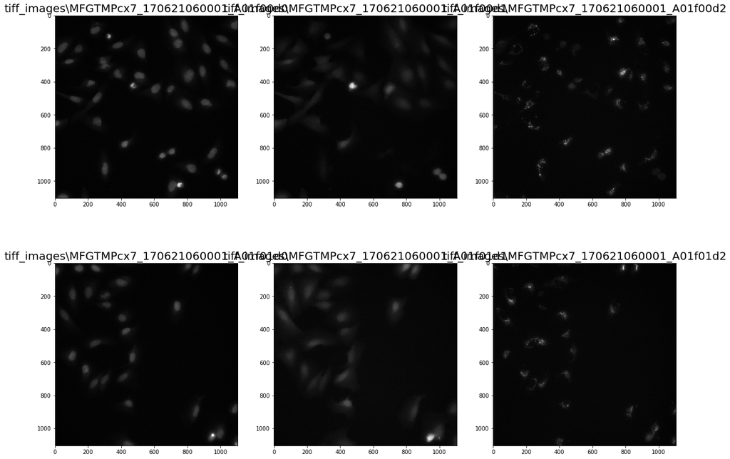

```python
from IPython.display import Image
Image('C:/Users/jxncx/Documents/BINP37/CP/qgsd/set1/quad.png')
```

Aside from this, most of the script is just following Nikolay's CellProfiler2Python notebook that he uploaded. The following script covers the 'Import Images to Python', 'Superimposing Color Channels', and 'Image Processing' sections. The numbers next to the packages in the beginning show where they were used, but this doesn't seem to be as useful in a jupyter notebook as it doesn't show the line numbers within cells...

```python
import glob #10
import numpy as np #38,39,40,60,85,87,95
import matplotlib.pyplot as plt #27:37,43:46,51,52,56,57,65,69,70,73,104:115
import os #82,92
from matplotlib import image #55,68
from skimage import io
from PIL import Image #23,24,25,42,50,61,84,94,96,97,122
from os import listdir #66,81

tiff = glob.glob('C:/Users/jxncx/Documents/BINP37/CP/qgsd/set1/tiff_images/*.tiff')

fig = plt.figure(figsize = (20,15))
for i,j in zip(tiff, range(len(tiff))):
    img = io.imread(i)
    plt.subplot(231 + j)
    plt.imshow(img[:,:], cmap = plt.cm.gray)
    plt.title(i.split('/')[8].split('.')[0], fontsize = 20)

img = io.imread('C:/Users/jxncx/Documents/BINP37/CP/qgsd/set1/tiff_images/MFGTMPcx7_170621060001_A01f10d0.tiff')
plt.tight_layout()
plt.show()

im1 = Image.open('tiff_images/MFGTMPcx7_170621060001_A01f07d0.tiff')
im2 = Image.open('tiff_images/MFGTMPcx7_170621060001_A01f07d1.tiff')
im3 = Image.open('tiff_images/MFGTMPcx7_170621060001_A01f07d2.tiff')

fig = plt.figure(figsize = (20,15))
plt.figure(figsize = (12,8))
plt.subplot(131)
plt.imshow(im1)
plt.subplot(132)
plt.imshow(im2)
plt.subplot(133)
plt.imshow(im3)
plt.tight_layout()
plt.show()

imarray1 = np.array(im1)
imarray2 = np.array(im2)
imarray3 = np.array(im3)

newImage = Image.merge('RGB', [im1, im2, im3])
plt.figure(figsize = (12,8))
plt.imshow(newImage)
plt.show()
#Image Processing
#We will perform image processing using Pillow Python module.

#Pillow...
testImage = Image.open('tiff_images/MFGTMPcx7_170621060001_A01f00d0.tiff')
plt.imshow(testImage)
plt.show()

#mit matplotlib
data = image.imread('tiff_images/MFGTMPcx7_170621060001_A01f00d0.tiff')
plt.imshow(data)
plt.show()

#Access pixel data using numpy
data = np.asarray(testImage)
image2 = Image.fromarray(data)

#Load all images in a directory
loaded = []
fig = plt.figure(figsize = (20,15))
tiffDir = listdir('tiff_images')
for filename, j in zip(tiffDir, range(len(tiffDir))):
    imgData = image.imread('tiff_images/' + filename)
    plt.subplot(231 + j)
    plt.imshow(imgData)
    loaded.append(imgData)
    print('> loaded %s %s' % (filename, imgData.shape))
plt.show()
#For some reason this produces different output than
#Nikolai's notebook, also produces a ValueError num must be 1...
#Which has to do with matplotlib's subplot method

#Image downsizing, images get reduced to 100x100
#File size is about 1/100th of the original
#Cool
tiffDir = listdir('tiff_images')
tiffDown = os.mkdir('tiffDownIm')
for filename in tiffDir:
    imgData = Image.open('tiff_images/' + filename)
    print('> loaded %s %s' % (filename, np.array(imgData).shape))
    imgData.thumbnail((100,100))
    print('> downsized image: {}'.format(np.array(imgData).shape))
    print('> saving downsized image {}'.format(filename))
    imgData.save('tiffDownIm/' + filename)

#Creating an augmented data set
tiffAug = os.mkdir('tiffAug')
for filename in tiffDir:
    imgData = Image.open('tiffDownIm/' + filename)
    print('> loaded %s %s' % (filename, np.array(imgData).shape))
    hFlip = imgData.transpose(Image.FLIP_LEFT_RIGHT)
    vFlip = imgData.transpose(Image.FLIP_TOP_BOTTOM)
    print('> saving augmented images for {}'.format(filename))
    imgData.save('tiffAug/' + filename)
    hFlip.save('tiffAug/augHorziontal' + filename)
    vFlip.save('tiffAug/augVertical' + filename)

#Rotated versions of images: 45, 90, etc...
fig = plt.figure(figsize = (20,15))
plt.subplot(131)
plt.title("Original Image", fontsize = 20)
plt.imshow(testImage)
plt.subplot(132)
plt.imshow(testImage.rotate(45))
plt.title("Rotate 45 Degrees", fontsize = 20)
plt.subplot(133)
plt.imshow(testImage.rotate(90))
plt.title("Rotate 90 degrees", fontsize = 20)
plt.show()

#Augmented data set with rotating each image from
#0 to 360 degrees by 2 degree step
counter = 0
for filename in tiffDir:
    print('Augmenting image {}'.format(filename))
    for i in range(0,360,2):
        imgData = Image.open('tiffDownIm/' + filename)
        rotImage = imgData.rotate(i)
        rotImage.save('tiffAug/aug_' + str(i) + '_' + filename)
    counter += 1
    print(str((counter/(len(tiffDir))) * 100) + "% Complete")
```

These were just various things we can do with images using python. The next part of the notebook was the CIFAR10 data set which we can briefly go over and post the code for. Here's the quoted information from Nikolay's notebook:

"Here for warming up purposes we will use a Convolutional Neural Network (CNN) built using Keras for image classification task using CIFAR10 image data set. The CIFAR-10 dataset consists of 60,000 photos divided into 10 classes (hence the name CIFAR-10). Classes include common objects such as airplanes, automobiles, birds, cats and so on. The dataset is split in a standard way, where 50,000 images are used for training a model and the remaining 10,000 for evaluating its performance. The photos are in color with red, green and blue components, but are small measuring 32 by 32 pixel squares."

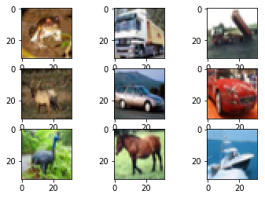

```python
import numpy as np
from keras.datasets import cifar10
from keras.models import Sequential
from keras.layers import Dense
from keras.layers import Dropout
from keras.layers import Flatten
from keras.constraints import maxnorm
from keras.optimizers import SGD
from keras.layers.convolutional import Conv2D
from keras.layers.convolutional import MaxPooling2D
from keras.utils import np_utils
from keras import backend as K
from matplotlib import pyplot as plt
from scipy.misc import toimage

(xTrain, yTrain), (xTest, yTest) = cifar10.load_data()

for i in range(0,9):
    plt.subplot(330 + 1 + i)
    plt.imshow(toimage(xTrain[i]))
plt.show()

K.set_image_dim_ordering('th')

seed = 7
np.random.seed(seed)

xTrain = xTrain.astype('float32')
xTest = xTest.astype('float32')
xTrain = xTrain / 255.0
xTest = xTest / 255.0

yTrain = np_utils.to_categorical(yTrain)
yTest = np_utils.to_categorical(yTest)
numClasses = yTest.shape[1]
```

Up to here, it sets up some basic variables that we'll need for the model and shows some examples of the images we're working with. Now, the actual model is built and compiled:

```python
#Model time
model = Sequential()
model.add(Conv2D(32, (3,3), input_shape = (3,32,32), padding = 'same',
                 activation = 'relu', kernel_constraint = maxnorm(3)))
model.add(Dropout(0.2))
model.add(Conv2D(32, (3,3), activation = 'relu', padding = 'same',
                 kernel_constraint = maxnorm(3)))
model.add(MaxPooling2D(pool_size = (2,2)))
model.add(Flatten())
model.add(Dense(512, activation = 'relu', kernel_constraint = maxnorm(3)))
model.add(Dropout(0.5))
model.add(Dense(numClasses, activation = 'softmax'))

#Compile time
epochs = 25
lrate = 0.01
decay = lrate/epochs
sgd = SGD(lr = lrate, momentum = 0.9, decay = decay,
          nesterov = False)
model.compile(loss = 'categorical_crossentropy', optimizer = sgd,
              metrics = ['accuracy'])
print(model.summary())

#Fitting time
model.fit(xTrain, yTrain, validation_data = (xTest, yTest), epochs = epochs,
          batch_size = 32)
scores = model.evaluate(xTest, yTest, verbose = 0)
print("Accuracy : %.2f%%" (scores[1] * 100))
```

```
_________________________________________________________________
Layer (type)                 Output Shape              Param #
=================================================================
conv2d_1 (Conv2D)            (None, 32, 32, 32)        896
_________________________________________________________________
dropout_1 (Dropout)          (None, 32, 32, 32)        0
_________________________________________________________________
conv2d_2 (Conv2D)            (None, 32, 32, 32)        9248
_________________________________________________________________
max_pooling2d_1 (MaxPooling2 (None, 32, 16, 16)        0
_________________________________________________________________
flatten_1 (Flatten)          (None, 8192)              0
_________________________________________________________________
dense_1 (Dense)              (None, 512)               4194816
_________________________________________________________________
dropout_2 (Dropout)          (None, 512)               0
_________________________________________________________________
dense_2 (Dense)              (None, 10)                5130
=================================================================
Total params: 4,210,090
Trainable params: 4,210,090
Non-trainable params: 0
_________________________________________________________________
None
Train on 50000 samples, validate on 10000 samples
```

[output not shown]

```python
from PIL import Image
from keras.models import Sequential
from keras.layers import Dense
from keras.layers import Dropout
from keras.layers import Flatten
from keras.constraints import maxnorm
from keras.optimizers import SGD
from keras.layers.convolutional import Conv2D
from keras.layers.convolutional import MaxPooling2D
from keras.utils import np_utils
from keras import backend as K
import glob
import numpy as np
fileNames = glob.glob('C:/Users/jxncx/Documents/BINP37/NOTEBOOK/CELLCLASS1/tiffDownIm/*.tiff')
images = [Image.open(i) for i in fileNames]
imgnp = [np.array(i) for i in images]
imgnp = [np.expand_dims(np.expand_dims(i, axis = 0)
        , axis = 0) for i in imgnp]

trainValue = 294
testValue = 126

xTrain = np.concatenate((imgnp[0:trainValue]), axis = 0)
xTest = np.concatenate((imgnp[trainValue:]), axis = 0)
yTrain = [0 for i in range(int(trainValue/2))]
secondClass = [1 for i in range(int(trainValue/2))]
yTrain.extend(secondClass)
yTrain = np.array(yTrain)
yTest = [0 for i in range(int(testValue/2))]
secondClass = [1 for i in range(int(testValue/2))]
yTest.extend(secondClass)
yTest = np.array(yTest)

K.set_image_dim_ordering('th')
seed = 7
np.random.seed(seed)

xTrain = xTrain.astype('float32') / 255.0
xTest = xTest.astype('float32') / 255.0
xTrain.reshape(trainValue,100,100,1)
xTest.reshape(testValue,100,100,1)
yTrain = np_utils.to_categorical(yTrain)
yTest = np_utils.to_categorical(yTest)
numClasses = yTest.shape[1]

#Model time
model = Sequential()

model.add(Conv2D(100, (3, 3), input_shape=(1, 100, 100), padding='same', activation='relu',
                 kernel_constraint=maxnorm(3)))
model.add(Dropout(0.2))
model.add(Conv2D(100, (3, 3), activation='relu', padding='same', kernel_constraint=maxnorm(3)))
model.add(MaxPooling2D(pool_size=(2, 2)))
model.add(Flatten())
model.add(Dense(10, activation='relu', kernel_constraint=maxnorm(3)))
model.add(Dropout(0.5))
model.add(Dense(numClasses, activation='sigmoid'))

epochs = 15
lrate = 0.01
decay = lrate/epochs
sgd = SGD(lr = lrate, momentum = 0.9, decay = decay, nesterov = False)
model.compile(loss = 'binary_crossentropy', optimizer = sgd,
              metrics = ['accuracy'])
print(model.summary())

#Training the model
model.fit(xTrain, yTrain, validation_data = (xTest, yTest),
          epochs = epochs, batch_size = 1)

#final eval
scores = model.evaluate(xTest, yTest, verbose = 0)
print("Accuracy: %.2f%%" % (scores[1] * 100))
```

```python
import glob
import numpy as np
from PIL import Image
from sklearn.model_selection import train_test_split
##
from keras.models import Sequential
from keras.layers import Dense
from keras.layers import Dropout
from keras.layers import Flatten
from keras.constraints import maxnorm
from keras.optimizers import SGD
from keras.layers.convolutional import Conv2D
from keras.layers.convolutional import MaxPooling2D
from keras.utils import np_utils
from keras import backend as K
##

aug = glob.glob('C:/Users/jxncx/Documents/BINP37/NOTEBOOK/CASE/tiffAug/*tiff')
xImage = np.zeros(shape = (0,1,100,100))
yImage = []

for filename in aug:
    img = Image.open((filename))
    imgArray = np.array(img)
    imgArray = np.expand_dims(np.expand_dims(imgArray, axis = 0),
                              axis = 0)
    xImage = np.concatenate((xImage, imgArray), axis = 0)
    if 'f00' in filename:
        yImage.append(0)
    else:
        yImage.append(1)
print(xImage.shape)
yImage = np.array(yImage)
print(yImage.shape)
print(yImage[0:10])

xImageTrain, xImageTest, yImageTrain, yImageTest = train_test_split(xImage,
                                                                    yImage,
                                                                    test_size = 0.2)
print("The dimensions of xImageTrain and yImageTrain are",
      xImageTrain.shape, " and ", yImageTrain.shape, " respectively")
print("The dimensions of xImageTest and yImageTest are",
      xImageTest.shape, " and ", yImageTest.shape, " respectively")
##
K.set_image_dim_ordering('th')
seed = 7
np.random.seed(seed)
xImageTrain = xImageTrain.astype('float32') / 255.0
xImageTest = xImageTest.astype('float32') / 255.0
yImageTrain = np_utils.to_categorical(yImageTrain)
yImageTest = np_utils.to_categorical(yImageTest)
numClasses = yImageTest.shape[1]

#Model
model = Sequential()
model.add(Conv2D(100, kernel_size=(3, 3), input_shape=(1, 100, 100), padding='same', activation='relu',
                 kernel_constraint=maxnorm(3)))
model.add(Dropout(0.2))
model.add(Conv2D(100, kernel_size=(3, 3), activation='relu', padding='same', kernel_constraint=maxnorm(3)))
model.add(MaxPooling2D(pool_size=(2, 2)))
model.add(Flatten())
model.add(Dense(512, activation = 'relu', kernel_constraint = maxnorm(3)))
model.add(Dropout(0.5))
model.add(Dense(numClasses, activation = 'sigmoid'))
# Compile model
epochs = 5
lrate = 0.01
decay = lrate / epochs
sgd = SGD(lr = lrate, momentum = 0.9, decay = decay, nesterov = False)
model.compile(loss = 'binary_crossentropy', optimizer = sgd, metrics = ['accuracy'])
print(model.summary())
estimator = model.fit(xImageTrain, yImageTrain, validation_split = 0.2, shuffle = True,
                      epochs = epochs, batch_size = 5)
print("Training Accuracy: ",estimator.history['acc'][-1])
print("Validation Accuracy: ",estimator.history['val_acc'][-1])
```

Aside from working on Nikolay's notebook, different pipelines like the quality control pipeline were used with CellProfiler. Sonja had sent a modified pipeline that works with CellProfiler3 and I'm now working with that.